# Modelos Lineares Bayesianos

Regressão Múltipla, ANOVA e ANCOVA — Capítulo 7 (Kinas & Andrade)

Autor

CE-062C — Tópicos: Modelagem Bayesiana

Data de Publicação

15 de abril de 2026

```r
library(tidyverse)
library(MASS)
library(patchwork)
library(viridis)
library(GGally)
theme_set(theme_bw(base_size = 14))
set.seed(2025)
```

# 1 Regressão Linear Múltipla

## 1.1 Formulação do Modelo

O modelo de regressão linear simples é generalizado de forma direta quando há $k-1$ variáveis preditoras quantitativas $x_j$, $j = 1, \ldots, k-1$. O modelo para a $i$-ésima observação é:

$$y_i = \beta_0 + \beta_1 x_{1,i} + \beta_2 x_{2,i} + \cdots +
\beta_{k-1} x_{k-1,i} + w_i$$

com $w_i \overset{\text{perm}}{\sim} N(0, \sigma)$, isto é, os erros são permutáveis com distribuição normal, média zero e desvio padrão constante $\sigma$ (homocedasticidade).

Na notação matricial compacta, com $\mathbf{X}$ sendo a matriz de planejamento $n \times k$ (incluindo a coluna de uns para o intercepto) e $\boldsymbol{\beta} = (\beta_0, \beta_1, \ldots, \beta_{k-1})^\top$:

$$\mathbf{y} = \mathbf{X}\boldsymbol{\beta} + \mathbf{w},
\quad \mathbf{w} \sim N_n(\mathbf{0},\, \sigma^2 \mathbf{I})$$

## 1.2 Distribuições Posteriores (Priori de Jeffreys)

Adotando a priori não-informativa de Jeffreys $p(\beta_0, \ldots, \beta_{k-1}, \sigma^2) \propto 1/\sigma^2$ e com os dados $D = \{(\mathbf{x}_i, y_i) : i = 1, \ldots, n\}$, as distribuições posteriores marginais são:

**Nota**

**Solução 7.2 (Kinas & Andrade)**

$$p(\beta_0 \mid D) \sim \text{St}(n-k,\; b_0,\; S_{\beta_0})$$

$$p(\beta_j \mid D) \sim \text{St}(n-k,\; b_j,\; S_{\beta_j}),
\quad j = 1, \ldots, k-1$$

$$p(\sigma^2 \mid D) \sim \text{GInv}\!\left(
\frac{n-k}{2},\; \frac{n-k}{2}S_e^2\right)$$

Os valores $b_0, \ldots, b_{k-1}$ são as estimativas de mínimos quadrados, $S_e^2$ é a variância residual, e $S_{\beta_j}$ são os parâmetros de escala equivalentes à raiz quadrada da diagonal de $S_e^2 V_\beta$, com $V_\beta = (\mathbf{X}^\top \mathbf{X})^{-1}$.

A posterior conjunta não tem forma fechada conveniente para simulação direta, mas a estrutura hierárquica $\boldsymbol{\beta} \mid \sigma^2, D$ é gaussiana, o que sugere o seguinte **algoritmo de simulação**:

1. Simular $\tau^{(l)} \sim \text{Gamma}\!\left(\dfrac{n-k}{2},\; \dfrac{n-k}{2}S_e^2\right)$ para $l = 1, \ldots, m$;
2. Calcular $\sigma^{2(l)} = 1/\tau^{(l)}$;
3. Simular $\boldsymbol{\beta}^{(l)} \sim N_k\!\left(\hat{\boldsymbol{\beta}},\; \sigma^{2(l)} V_\beta\right)$.

## 1.3 Padronização das Covariáveis

Antes de ajustar o modelo, é conveniente **padronizar** as variáveis preditoras:

$$z_j = \frac{x_j - \bar{x}_j}{S_{x_j}}$$

Essa transformação produz dois benefícios importantes:

- **Remove a correlação** dos coeficientes, pois centraliza cada variável em torno de zero;
- **Torna os coeficientes comparáveis**: cada $\beta_j$ expressa o efeito de um incremento de um desvio padrão em $x_j$ sobre $y$.

## 1.4 Exemplo: Captura de Tubarão-Martelo

Os dados de Kotas et al. (2005) contêm capturas de tubarão-martelo (*Sphyrna* spp.) em espinhel pelágico. Modelamos $y = \log(\text{capkg})$ em função das preditoras padronizadas $z_1 = [\log(\text{temp}) - \overline{\log(\text{temp})}]/S_{\log(\text{temp})}$ e $z_2 = [\log(\text{nanz}) - \overline{\log(\text{nanz})}]/S_{\log(\text{nanz})}$, onde `capkg` representa a captura em kg, `temp` a temperatura superficial do mar, e `nanz` é o número de anzóis (esforço de pesca).

```r
## Dados do tubarao-martelo (Kotas et al., 2005)
## Reproduzindo estrutura do Exemplo 7.2 com dados simulados
set.seed(42)
n <- 53
temp_raw <- runif(n, 16, 27)
nanz_raw <- round(runif(n, 1500, 20000))
capkg_raw <- exp(
    6.14 - 0.23 * scale(log(temp_raw))[, 1] +
    1.23 * scale(log(nanz_raw))[, 1] +
    rnorm(n, 0, 0.72)
)
martelo_sim <- tibble(
    temp = temp_raw,
    nanz = nanz_raw,
    capkg = capkg_raw
)
```

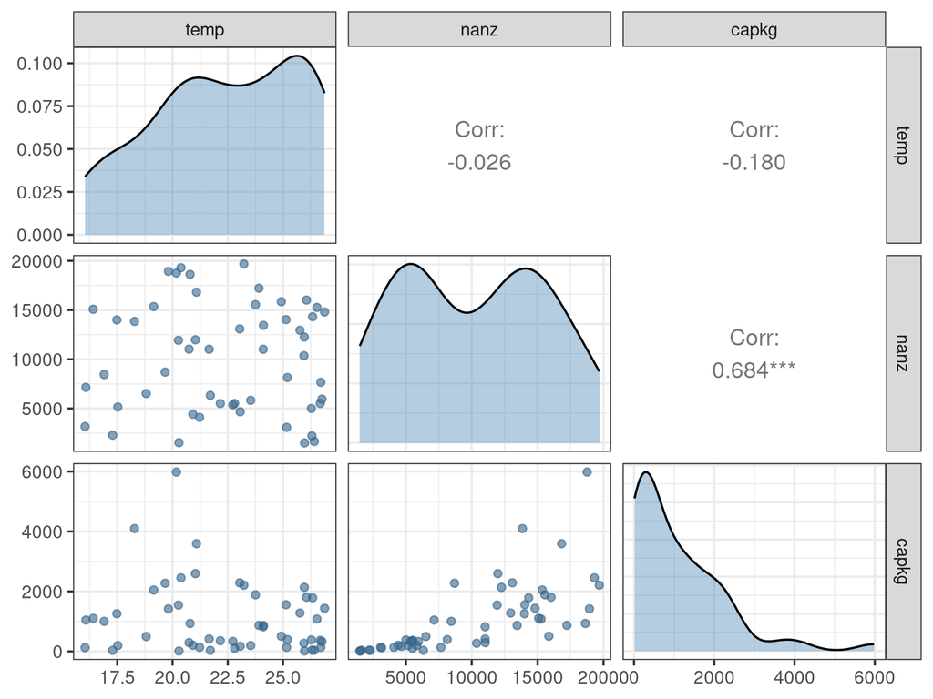

Diagramas de dispersao do tubarao-martelo (escala original).

```r
ggpairs(martelo_sim,
    lower = list(continuous = wrap("points", alpha = 0.6,
        color = "steelblue4")),
    diag = list(continuous = wrap("densityDiag", fill = "steelblue",
        alpha = 0.4))) +
    theme(strip.text = element_text(size = 11))
```

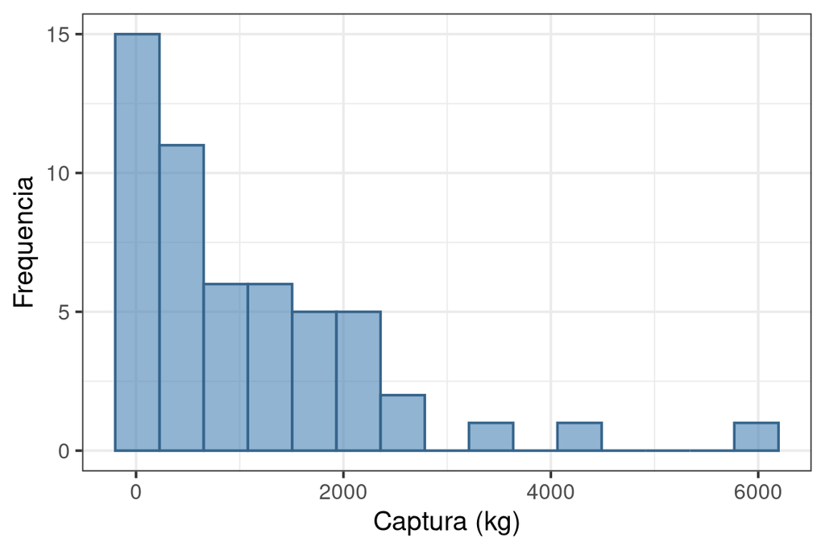

Distribuicao da captura (kg) na escala original.

```r
ggplot(martelo_sim, aes(x = capkg)) +
    geom_histogram(bins = 15, fill = "steelblue", alpha = 0.6,
        color = "steelblue4") +
    labs(x = "Captura (kg)", y = "Frequencia")
```

```r
## Transformacoes e padronizacao
y <- log(martelo_sim$capkg)
x1 <- log(martelo_sim$temp)
x2 <- log(martelo_sim$nanz)
z1 <- (x1 - mean(x1)) / sd(x1)
z2 <- (x2 - mean(x2)) / sd(x2)
```

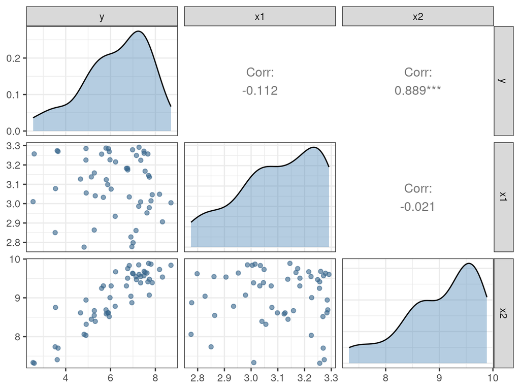

Dispersao na escala log de capkg, temp e nanz.

```r
ggpairs(tibble(y, x1, x2),
    lower = list(continuous = wrap("points", alpha = 0.6,
        color = "steelblue4")),
    diag = list(continuous = wrap("densityDiag", fill = "steelblue",
        alpha = 0.4))) +
    theme(strip.text = element_text(size = 11))
```

```r
## Ajuste por minimos quadrados (estrutura para a posterior)
martelo_lm <- lm(y ~ z1 + z2)
se <- summary(martelo_lm)$sigma
est <- coef(martelo_lm)
Vbeta <- summary(martelo_lm)$cov.unscaled

## Simulacao da distribuicao posterior conjunta (m = 5000)
m <- 5000
prec <- rgamma(m, (n - 3) / 2, se^2 * (n - 3) / 2)
sig2 <- 1 / prec

beta_post <- t(sapply(seq_len(m), function(l)
    mvrnorm(1, est, sig2[l] * Vbeta)))
colnames(beta_post) <- c("beta0", "beta1", "beta2")
bind_cols(beta_post, sigma2 = sig2) |>
    as_tibble()
```

```
# A tibble: 5,000 × 4
   beta0   beta1 beta2 sigma2
   <dbl>   <dbl> <dbl>  <dbl>
 1  6.27 -0.208   1.37  0.511
 2  6.36 -0.201   1.29  0.387
 3  6.20  0.0228  1.36  0.506
 4  6.12 -0.213   1.33  0.471
 5  6.22 -0.203   1.40  0.337
 6  6.20 -0.0621  1.19  0.393
 7  6.10 -0.156   1.35  0.566
 8  6.23 -0.343   1.24  0.507
 9  6.45 -0.0759  1.40  0.756
10  6.02 -0.111   1.08  0.630
# ℹ 4,990 more rows
```

```r
## Sumario posterior
sumario <- apply(
    cbind(beta_post, sigma = sqrt(sig2)), 2,
    function(x) c(
                    "2.5%" = quantile(x, 0.025),
                    "Mediana" = median(x),
                    "97.5%" = quantile(x, 0.975),
                    "Media" = mean(x),
                    "dp" = sd(x)
                )
)
knitr::kable(
           round(t(sumario), 3),
           caption = paste(
               "Sumario das distribuicoes posteriores marginais —",
               "regressao multipla (dados simulados, estrutura de",
               "Kotas et al., 2005)."
           )
       )
```

Sumario das distribuicoes posteriores marginais — regressao multipla (dados simulados, estrutura de Kotas et al., 2005).

|  | 2.5%.2.5% | Mediana | 97.5%.97.5% | Media | dp |
| --- | --- | --- | --- | --- | --- |
| beta0 | 6.033 | 6.226 | 6.410 | 6.226 | 0.095 |
| beta1 | -0.335 | -0.136 | 0.054 | -0.137 | 0.098 |
| beta2 | 1.125 | 1.318 | 1.508 | 1.317 | 0.097 |
| sigma | 0.568 | 0.683 | 0.848 | 0.689 | 0.071 |

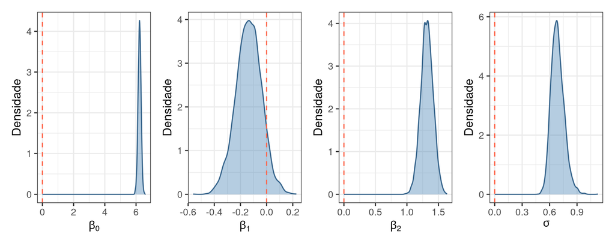

Distribuicoes posteriores marginais dos parametros da regressao multipla.

```r
df_post <- as.data.frame(beta_post) |>
    mutate(sigma = sqrt(sig2))

nomes <- c(
    beta0 = expression(beta[0]),
    beta1 = expression(beta[1]),
    beta2 = expression(beta[2]),
    sigma = expression(sigma)
)

plist <- lapply(names(nomes), function(par) {
    ggplot(df_post, aes(x = .data[[par]])) +
        geom_density(fill = "steelblue", alpha = 0.4,
            color = "steelblue4") +
        geom_vline(xintercept = 0, linetype = "dashed",
            color = "tomato") +
        labs(x = nomes[[par]], y = "Densidade") +
        theme(axis.title.x = element_text(size = 13))
})
wrap_plots(plist, nrow = 1)
```

# 2 Análise de Variância (ANOVA)

## 2.1 Formulação do Modelo

Quando todas as variáveis preditoras são **categóricas**, o modelo linear assume a estrutura:

$$y_{g,i} = \mu_g + w_{g,i},
\quad g = 1, \ldots, G,\quad i = 1, \ldots, n_g$$

onde $\mu_g$ é a média do $g$-ésimo nível (efeito fixo) e $w_{g,i} \overset{\text{perm}}{\sim} N(0, \sigma)$. A hipótese de **homocedasticidade** (variância igual entre grupos) é central.

Para o modelo de um fator fixo, as estatísticas suficientes são:

$$\bar{y}_g = \frac{1}{n_g}\sum_{i=1}^{n_g} y_{g,i},\quad
SQ_g = \sum_{i=1}^{n_g}(y_{g,i} - \bar{y}_g)^2,\quad
n = \sum_{g=1}^G n_g,\quad
S_e^2 = \frac{\sum_{g=1}^G SQ_g}{n - G}$$

## 2.2 Distribuições Posteriores (Priori de Jeffreys)

**Nota**

**Solução 7.3 (Kinas & Andrade)**

Sob a priori $p(\mu_1, \ldots, \mu_G, \sigma) \propto 1/\sigma^2$:

$$p(\mu_g \mid D) \sim \text{St}\!\left(n - G,\; \bar{y}_g,\;
\frac{S_e}{\sqrt{n_g}}\right)$$

$$p(\sigma^2 \mid D) \sim \text{GInv}\!\left(
\frac{n-G}{2},\; \frac{n-G}{2}S_e^2\right)$$

O algoritmo de simulação é análogo ao da regressão:

1. Simular $\tau^{(l)} \sim \text{Gamma}\!\left(\dfrac{n-G}{2},\; \dfrac{n-G}{2}S_e^2\right)$;
2. Calcular $\sigma^{2(l)} = 1/\tau^{(l)}$;
3. Simular $(\mu_1^{(l)}, \ldots, \mu_G^{(l)}) \sim N_G\!\left((\bar{y}_1, \ldots, \bar{y}_G),\; \sigma^{2(l)} V_\mu\right)$, com $V_\mu = \text{diag}(1/n_1, \ldots, 1/n_G)$.

## 2.3 Conexão com a ANOVA Frequentista

Na abordagem frequentista, o foco é testar $H_0: \mu_1 = \cdots = \mu_G$. A estatística de teste é a razão entre variâncias:

$$F = \frac{\text{QMTr}}{\text{QMR}}
= \frac{SQTr/(G-1)}{SQR/(n-G)}
\overset{H_0}{\sim} F(G-1,\; n-G)$$

onde $SQTr = SQT - SQR = \sum_{g,i}(y_{g,i} - \bar{\bar{y}})^2 - \sum_g SQ_g$.

Na **abordagem bayesiana**, o foco recai nas distribuições posteriores de cada $\mu_g$ e nas probabilidades de interesse sobre **contrastes**, como $P(\mu_a - \mu_b > 0 \mid D)$ — sem a rigidez de uma decisão binária.

## 2.4 Exemplo: CPUE do Tubarão-Martelo por Área de Pesca

O objetivo é comparar as médias de CPUE entre 3 áreas de pesca. A Captura por Unidade de Esforço (CPUE) é obtida pela razão entre a captura e uma medida padrão de esforço de pesca, e pode ser considerada como proporcional à abundância de uma população.

```r
## Dados simulados com estrutura do Exemplo 7.3 (Kotas et al., 2005)
## Tres areas de pesca (9, 14, 15); resposta: log(CPUE)
set.seed(123)
ng <- c(area9 = 21, area14 = 11, area15 = 21)
G <- length(ng)
mu_verd <- c(4.08, 5.00, 4.22)
sigma_verd <- 0.69

lcpue <- unlist(mapply(
    function(mu, n) rnorm(n, mu, sigma_verd),
    mu_verd, ng
))
area <- rep(c("9", "14", "15"), times = ng)
df_anova <- data.frame(lcpue = lcpue, area = factor(area))

## Estatisticas suficientes
fnsq <- function(x) sum((x - mean(x))^2)
ygbar <- tapply(lcpue, area, mean)
sqg <- tapply(lcpue, area, fnsq)
ng_obs <- tapply(lcpue, area, length)
nG <- sum(ng_obs)
se2G <- sum(sqg) / (nG - G)

## Simulacao da posterior conjunta (m = 3000)
m <- 3000
Vmu <- diag(1 / as.numeric(ng_obs))
tauG <- rgamma(m, (nG - G) / 2, se2G * (nG - G) / 2)
varG <- 1 / tauG

muGpost <- t(sapply(seq_len(m), function(l)
    mvrnorm(1, as.numeric(ygbar), varG[l] * Vmu)))
colnames(muGpost) <- paste0("mu", names(ygbar))

## Posterior na escala original da CPUE
emuGpost <- exp(muGpost)

## Probabilidade P(mu15 - mu9 > 0 | dados)
prob15_9 <- mean(emuGpost[, 3] - emuGpost[, 1] > 0)
prob15_9
```

```
[1] 0.003666667
```

```r
## Diferenca posterior
dif15_9 <- emuGpost[, 3] - emuGpost[, 1]
round(c(quantile(dif15_9, c(0.025, 0.5, 0.975)),
    media = mean(dif15_9), dp = sd(dif15_9)), 2)
```

```
   2.5%     50%   97.5%   media      dp
-117.91  -59.31  -16.65  -61.46   25.78
```

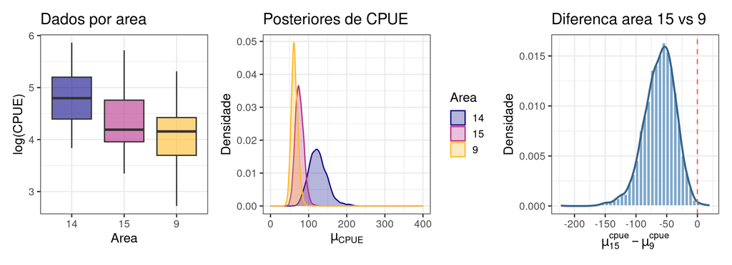

```r
p1 <- ggplot(df_anova, aes(x = area, y = lcpue, fill = area)) +
    geom_boxplot(alpha = 0.6, show.legend = FALSE) +
    scale_fill_viridis_d(option = "C", end = 0.85) +
    labs(x = "Area", y = "log(CPUE)", title = "Dados por area")

df_mu <- as.data.frame(emuGpost) |>
    pivot_longer(everything(), names_to = "area",
                 values_to = "cpue") |>
    mutate(area = gsub("mu", "", area))

p2 <- ggplot(df_mu, aes(x = cpue, color = area, fill = area)) +
    geom_density(alpha = 0.3) +
    scale_color_viridis_d(option = "C", end = 0.85) +
    scale_fill_viridis_d(option = "C", end = 0.85) +
    labs(x = expression(mu[CPUE]), y = "Densidade",
         title = "Posteriores de CPUE",
         color = "Area", fill = "Area") +
    xlim(0, 400)

df_dif <- data.frame(dif = dif15_9)
p3 <- ggplot(df_dif, aes(x = dif)) +
    geom_histogram(aes(y = after_stat(density)), bins = 40,
                   fill = "steelblue", alpha = 0.7,
                   color = "white") +
    geom_density(color = "steelblue4", linewidth = 1) +
    geom_vline(xintercept = 0, linetype = "dashed",
               color = "tomato") +
    labs(x = expression(mu[15]^{cpue} - mu[9]^{cpue}),
         y = "Densidade", title = "Diferenca area 15 vs 9")

p1 + p2 + p3
```

Outra forma de analisar as diferenças é por meio das distribuições acumuladas das posteriores.

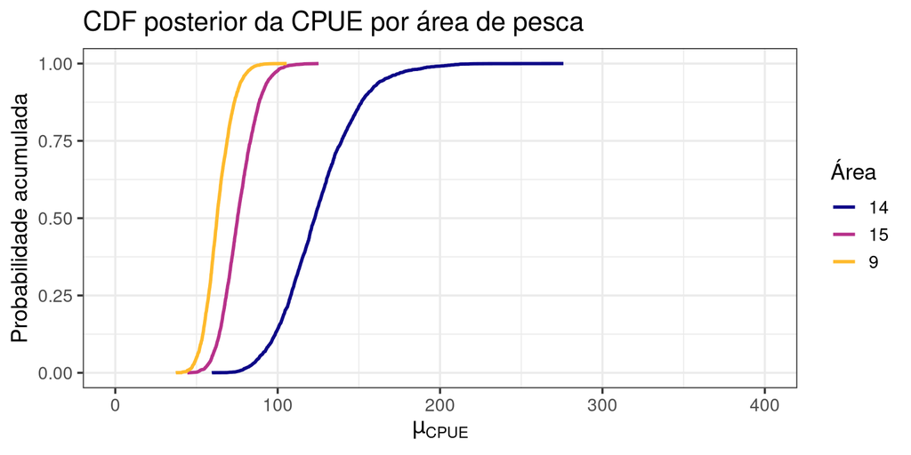

Distribuições posteriores acumuladas (CDF) da CPUE por área de pesca.

```r
df_cdf <- as.data.frame(emuGpost) |>
    pivot_longer(everything(), names_to = "area", values_to = "cpue") |>
    mutate(area = gsub("mu", "", area)) |>
    group_by(area) |>
    arrange(cpue, .by_group = TRUE) |>
    mutate(cdf = seq(0, 1, length.out = n()))

ggplot(df_cdf, aes(x = cpue, y = cdf, color = area)) +
    geom_line(linewidth = 1) +
    scale_color_viridis_d(option = "C", end = 0.85) +
    xlim(0, 400) +
    labs(x = expression(mu[CPUE]), y = "Probabilidade acumulada",
         color = "Área",
         title = "CDF posterior da CPUE por área de pesca")
```

# 3 Exercícios

Os exercícios abaixo são selecionados da lista do Capítulo 7 de Kinas & Andrade para complementar os tópicos abordados.

## 3.1 Exercício 7.3 — Relação Peso-Comprimento da Cabrinha

Os dados abaixo correspondem ao comprimento (cm) e peso (kg) de 25 exemplares de cabrinha (*Prionotus punctatus*):

```r
comp_p <- c(10.2, 19.0, 22.3, 23.8, 24.9, 26.1, 26.9, 27.9,
            28.5, 29.2, 30.1, 31.0, 31.7, 32.4, 32.9, 33.3,
            34.1, 34.6, 35.5, 36.3, 37.0, 38.0, 39.0, 39.6, 43.0)
peso_p <- c(0.01, 0.09, 0.12, 0.18, 0.19, 0.23, 0.24, 0.31,
            0.33, 0.32, 0.33, 0.40, 0.45, 0.49, 0.67, 0.48,
            0.54, 0.63, 0.59, 0.65, 0.50, 0.81, 0.87, 0.71, 0.91)
prionotus <- data.frame(comp = comp_p, peso = peso_p)
```

Pretende-se ajustar o modelo alométrico $y = \beta_0 x^{\beta_1}$, onde $y$ é o peso e $x$ é o comprimento, e que na forma logaritmizada fica:

$$\log(y) = \beta_0' + \beta_1' \log(x) + v,\quad v \sim N(0, \sigma)$$

com $\beta_0' = \log(\beta_0)$ e $\beta_1' = \beta_1$.

**a)** Construa diagramas de dispersão de $y$ vs. $x$ e de $\log(y)$ vs. $\log(x)$. Justifique a adoção do modelo linear na escala logarítmica.

**b)** Usando a priori não-informativa de Jeffreys, obtenha uma amostra de tamanho $m = 3000$ da distribuição posterior conjunta de $(\beta_0', \beta_1', \sigma)$. Construa diagramas de dispersão de $\beta_0'$ vs. $\beta_1'$ e de $\beta_0$ vs. $\beta_1$ (escala original).

**c)** Represente as distribuições posteriores marginais de $\beta_0$ e $\beta_1$ com histogramas e calcule os ICr95%. Interprete o ICr95% para $\beta_1$, considerando que peixes isométricos têm $\beta_1 \approx 3$.

**d)** Construa a distribuição preditiva para o peso de um indivíduo com $x_p = 20$ cm. Apresente o ICr99% e avalie a precisão da predição.

## 3.2 Exercício 7.4 — Regressão Múltipla para Fósforo no Solo

Os dados abaixo (Snedecor & Cochran, 1989, p. 335) descrevem fósforo inorgânico ($X_1$, ppm), orgânico ($X_2$, ppm) e disponível para as plantas ($Y$, ppm) em amostras de solo:

```r
X1 <- c(0.4, 0.4, 3.1, 0.6, 4.7, 1.7, 9.4, 10.1, 11.6,
        12.6, 10.9, 23.1, 23.1, 21.6, 23.1, 1.9, 29.9)
X2 <- c(53, 23, 19, 34, 24, 65, 44, 31, 29,
        58, 37, 46, 50, 44, 56, 36, 51)
Y <- c(64, 60, 71, 61, 54, 77, 81, 93, 93,
       51, 76, 96, 77, 93, 95, 54, 99)
fosforo <- data.frame(Y = Y, X1 = X1, X2 = X2)
```

**a)** Construa diagramas de dispersão de $Y$ vs. $X_1$ e $Y$ vs. $X_2$.

**b)** Ajuste um modelo bayesiano de regressão múltipla com variáveis explanatórias padronizadas e priori de Jeffreys. Obtenha $m = 1000$ amostras da distribuição posterior.

**c)** Represente graficamente e construa um sumário das distribuições posteriores marginais de todos os parâmetros.

**d)** Obtenha 1000 amostras da distribuição preditiva para $X_1 = 15\,\text{ppm}$ e $X_2 = 40\,\text{ppm}$.

**e)** Apresente o sumário e o gráfico da distribuição preditiva posterior.

## 3.3 Exercício 7.5 — ANOVA para Comprimento de Tartarugas

Em um estudo sobre quatro praias de desova, pesquisadores mediram o comprimento curvilíneo da carapaça (CC, em cm):

```r
praia <- c(1, 1, 1, 1, 2, 2, 2, 3, 3, 3, 3, 3, 3, 4, 4, 4, 4, 4)
CC <- c(100.4, 96.7, 96.3, 96.2,
        94.6, 92.8, 89.0,
        92.2, 96.6, 95.3, 95.9, 93.2, 93.2,
        95.3, 97.3, 99.3, 99.0, 96.4)
tartarugas <- data.frame(praia = factor(praia), CC = CC)
```

Considere o modelo de fatores fixos: $y_{g,i} = \mu_g + w_{g,i}$, com $w_{g,i} \sim N(0, \sigma)$.

**a)** Calcule médias e variâncias por praia; represente com boxplots.

**b)** Usando a priori de Jeffreys, retire $m = 3000$ amostras da distribuição posterior conjunta de $(\mu_1, \mu_2, \mu_3, \mu_4, \sigma)$.

**c)** Calcule sumários e represente as distribuições posteriores marginais de $\mu_g$, $g = 1, \ldots, 4$.

**d)** Calcule $P(\mu_3 > \mu_2 \mid D)$.

# 4 Gabarito dos Exercícios

## 4.1 Gabarito — Exercício 7.3

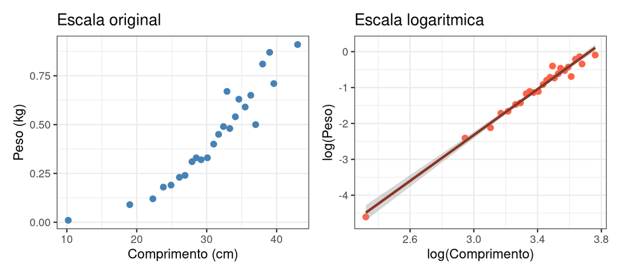

Exercicio 7.3a: dispersao na escala original (esq.) e logaritmica (dir.).

```r
p1 <- ggplot(prionotus, aes(x = comp, y = peso)) +
    geom_point(color = "steelblue", size = 2.5) +
    labs(x = "Comprimento (cm)", y = "Peso (kg)",
         title = "Escala original")
p2 <- ggplot(prionotus, aes(x = log(comp), y = log(peso))) +
    geom_point(color = "tomato", size = 2.5) +
    geom_smooth(method = "lm", se = TRUE, color = "tomato4") +
    labs(x = "log(Comprimento)", y = "log(Peso)",
         title = "Escala logaritmica")
p1 + p2
```

Na escala original a relação é claramente não-linear e a variância aumenta com $x$. Na escala logarítmica a relação é bem aproximada por uma reta e a dispersão é mais homogênea — o que justifica o modelo linear em $\log(y)$ vs. $\log(x)$.

```r
## b) Amostra posterior conjunta
y_p <- log(prionotus$peso)
x_p <- log(prionotus$comp)
n_p <- length(y_p)

prio_lm <- lm(y_p ~ x_p)
se_p <- summary(prio_lm)$sigma
est_p <- coef(prio_lm)
Vb_p <- summary(prio_lm)$cov.unscaled
m_p <- 3000

prec_p <- rgamma(m_p, (n_p - 2) / 2, se_p^2 * (n_p - 2) / 2)
sig2_p <- 1 / prec_p
beta_p <- t(sapply(seq_len(m_p), function(l)
    mvrnorm(1, est_p, sig2_p[l] * Vb_p)))
colnames(beta_p) <- c("b0l", "b1l")

## Conversao para escala original: beta0 = exp(b0'), beta1 = b1'
beta0_orig <- exp(beta_p[, "b0l"])
beta1_orig <- beta_p[, "b1l"]

df_b <- tibble(
    b0l = beta_p[, "b0l"],
    b1l = beta_p[, "b1l"],
    beta0 = beta0_orig,
    beta1 = beta1_orig
)
```

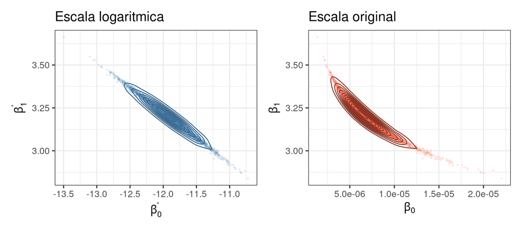

Exercicio 7.3b: posterior conjunta na escala log (esq.) e original (dir.).

```r
p1 <- ggplot(df_b, aes(x = b0l, y = b1l)) +
    geom_point(alpha = 0.1, color = "steelblue", size = 0.5) +
    stat_density_2d(color = "steelblue4", linewidth = 0.5) +
    labs(x = expression(beta[0]^"'"),
         y = expression(beta[1]^"'"),
         title = "Escala logaritmica")
p2 <- ggplot(df_b, aes(x = beta0, y = beta1)) +
    geom_point(alpha = 0.1, color = "tomato", size = 0.5) +
    stat_density_2d(color = "tomato4", linewidth = 0.5) +
    labs(x = expression(beta[0]), y = expression(beta[1]),
         title = "Escala original")
p1 + p2
```

```r
## c) Marginais e ICr95%
icr_b0 <- quantile(beta0_orig, c(0.025, 0.975))
icr_b1 <- quantile(beta1_orig, c(0.025, 0.975))
round(icr_b0, 5)
```

```
 2.5% 97.5%
0e+00 1e-05
```

```r
round(icr_b1, 3)
```

```
 2.5% 97.5%
3.002 3.390
```

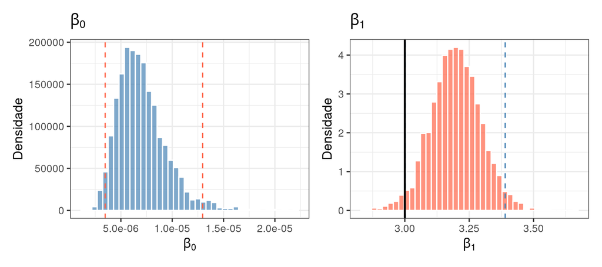

Exercicio 7.3c: posteriores marginais de beta0 e beta1 (escala original).

```r
p1 <- ggplot(df_b, aes(x = beta0)) +
    geom_histogram(aes(y = after_stat(density)), bins = 40,
                   fill = "steelblue", alpha = 0.7,
                   color = "white") +
    geom_vline(xintercept = icr_b0, linetype = "dashed",
               color = "tomato") +
    labs(x = expression(beta[0]), y = "Densidade",
         title = expression(beta[0]))
p2 <- ggplot(df_b, aes(x = beta1)) +
    geom_histogram(aes(y = after_stat(density)), bins = 40,
                   fill = "tomato", alpha = 0.7,
                   color = "white") +
    geom_vline(xintercept = icr_b1, linetype = "dashed",
               color = "steelblue") +
    geom_vline(xintercept = 3, linetype = "solid",
               color = "black", linewidth = 1) +
    labs(x = expression(beta[1]), y = "Densidade",
         title = expression(beta[1]))
p1 + p2
```

Neste caso, como o valor de referência e o limite inferior do intervalo de credibilidade são peraticamente iguais, outras medidas podem ser calculadas a partir da posterior. Por exemplo, podemos calcular $P(\beta_1 < 3)$, que pode ajudar a chegar à uma conclusão:

```r
mean(beta1_orig < 3)
```

```
[1] 0.02366667
```

```r
## e) Distribuicao preditiva para xp = 20 cm
xp <- log(20)
yhat_p <- beta_p[, "b0l"] + beta_p[, "b1l"] * xp
ytil_log <- rnorm(m_p, yhat_p, sqrt(sig2_p))
ytil_orig <- exp(ytil_log)

icr99 <- quantile(ytil_orig, c(0.005, 0.995))
round(icr99, 3)
```

```
 0.5% 99.5%
0.063 0.148
```

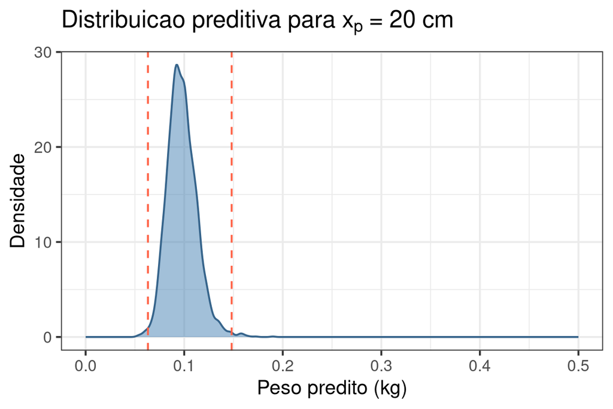

Exercicio 7.3e: distribuicao preditiva para comprimento xp = 20 cm.

```r
ggplot(data.frame(ytil = ytil_orig), aes(x = ytil)) +
    geom_density(fill = "steelblue", alpha = 0.5,
                 color = "steelblue4") +
    geom_vline(xintercept = icr99, linetype = "dashed",
               color = "tomato") +
    xlim(0, 0.5) +
    labs(x = "Peso predito (kg)", y = "Densidade",
         title = expression(
             paste("Distribuicao preditiva para ",
                   x[p], " = 20 cm")
         ))
```

O ICr99% para o peso de um indivíduo com 20 cm é [0.063, 0.148] kg. A amplitude evidencia incerteza preditiva considerável, reflexo tanto da incerteza paramétrica quanto da variabilidade individual $\sigma$.

## 4.2 Gabarito — Exercício 7.4

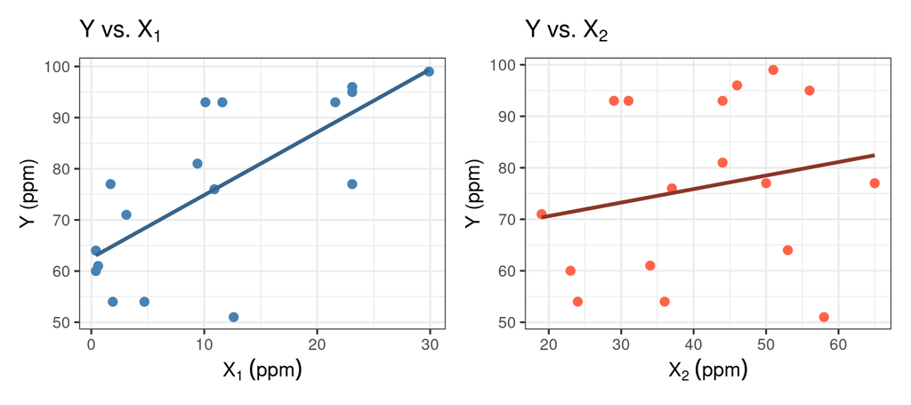

Exercicio 7.4a: fosforo disponivel (Y) em funcao de X1 e X2.

```r
p1 <- ggplot(fosforo, aes(x = X1, y = Y)) +
    geom_point(color = "steelblue", size = 2.5) +
    geom_smooth(method = "lm", se = FALSE, color = "steelblue4") +
    labs(x = expression(X[1]~(ppm)), y = "Y (ppm)",
         title = expression(Y~vs.~X[1]))

p2 <- ggplot(fosforo, aes(x = X2, y = Y)) +
    geom_point(color = "tomato", size = 2.5) +
    geom_smooth(method = "lm", se = FALSE, color = "tomato4") +
    labs(x = expression(X[2]~(ppm)), y = "Y (ppm)",
         title = expression(Y~vs.~X[2]))

p1 + p2
```

Ambas as variáveis apresentam associação positiva com $Y$, com $X_1$ mostrando relação mais forte e $X_2$ relação mais moderada.

```r
## b) Regressao multipla bayesiana com preditoras padronizadas
z1_f <- (X1 - mean(X1)) / sd(X1)
z2_f <- (X2 - mean(X2)) / sd(X2)
n_f <- length(Y)

fosforo_lm <- lm(Y ~ z1_f + z2_f)
se_f <- summary(fosforo_lm)$sigma
est_f <- coef(fosforo_lm)
Vb_f <- summary(fosforo_lm)$cov.unscaled
m_f <- 1000

prec_f <- rgamma(m_f, (n_f - 3) / 2, se_f^2 * (n_f - 3) / 2)
sig2_f <- 1 / prec_f
beta_f <- t(sapply(seq_len(m_f), function(l)
    mvrnorm(1, est_f, sig2_f[l] * Vb_f)))
colnames(beta_f) <- c("beta0", "beta1", "beta2")
```

```r
## c) Sumario e graficos
sumario_f <- apply(
    cbind(beta_f, sigma = sqrt(sig2_f)), 2,
    function(x) c(
        "2.5%" = quantile(x, 0.025),
        "Mediana" = median(x),
        "97.5%" = quantile(x, 0.975),
        "Media" = mean(x),
        "dp" = sd(x)
    )
)
knitr::kable(
    round(t(sumario_f), 2),
    caption = paste("Sumario posterior — regressao multipla",
                    "para fosforo disponivel.")
)
```

Sumario posterior — regressao multipla para fosforo disponivel.

|  | 2.5%.2.5% | Mediana | 97.5%.97.5% | Media | dp |
| --- | --- | --- | --- | --- | --- |
| beta0 | 70.03 | 76.05 | 82.79 | 76.08 | 3.17 |
| beta1 | 5.29 | 12.66 | 19.34 | 12.56 | 3.55 |
| beta2 | -8.08 | -1.15 | 4.90 | -1.36 | 3.46 |
| sigma | 8.94 | 12.63 | 19.09 | 13.02 | 2.62 |

Exercicio 7.4c: posteriores marginais — regressao multipla para fosforo.

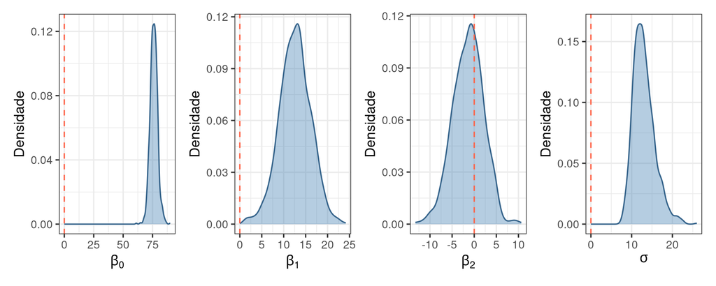

Exercicio 7.4c: posteriores marginais — regressao multipla para fosforo.

```r
df_f <- as.data.frame(cbind(beta_f, sigma = sqrt(sig2_f)))
nomes_f <- c(
    beta0 = expression(beta[0]),
    beta1 = expression(beta[1]),
    beta2 = expression(beta[2]),
    sigma = expression(sigma)
)

plist_f <- lapply(names(nomes_f), function(par) {
    ggplot(df_f, aes(x = .data[[par]])) +
        geom_density(fill = "steelblue", alpha = 0.4,
                     color = "steelblue4") +
        geom_vline(xintercept = 0, linetype = "dashed",
                   color = "tomato") +
        labs(x = nomes_f[[par]], y = "Densidade")
})
wrap_plots(plist_f, nrow = 1)
```

```r
## d) e e) Distribuicao preditiva para X1=15, X2=40
x1_new <- (15 - mean(X1)) / sd(X1)
x2_new <- (40 - mean(X2)) / sd(X2)
yhat_f <- beta_f[, "beta0"] + beta_f[, "beta1"] * x1_new +
    beta_f[, "beta2"] * x2_new
ytil_f <- rnorm(m_f, yhat_f, sqrt(sig2_f))

icr95_f <- quantile(ytil_f, c(0.025, 0.975))
round(icr95_f, 1)
```

```
 2.5% 97.5%
 53.3 110.0
```

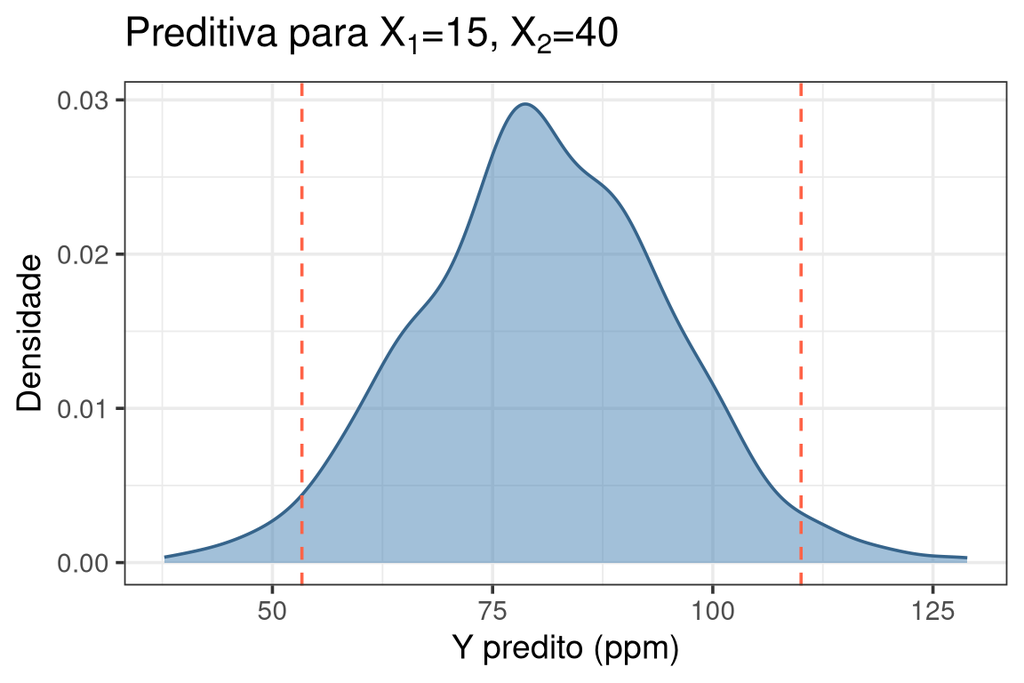

Exercicio 7.4d-e: distribuicao preditiva para X1=15, X2=40.

```r
ggplot(data.frame(ytil = ytil_f), aes(x = ytil)) +
    geom_density(fill = "steelblue", alpha = 0.5,
                 color = "steelblue4") +
    geom_vline(xintercept = icr95_f, linetype = "dashed",
               color = "tomato") +
    labs(x = "Y predito (ppm)", y = "Densidade",
         title = expression(
             paste("Preditiva para ", X[1], "=15, ", X[2], "=40")
         ))
```